# Tarea Diplomado: Análisis de caso: Mortalidad en MarineFjordland en 2021

Carolina San Martin

2022-07-01

## Titulo: “Análisis de caso: Mortalidad en MarineFjordland en 2021”

## 1.- Descripción del caso a resolver

- SiteName (Nombre centro)
- ManagementArea (Area de Manejo) Figura 1
- Case (Caso 1/0)
- MeanWaterTemperature (Temperatura promedio)
- Density (Densidad)
- Company (Compañía)
- Vaccine (Tipo de vacuna)
- SeaLice (Presencia de Sealice)
- GillDisease (Enfermedad branquial )
- FailedSmolt (Calidad smolt)

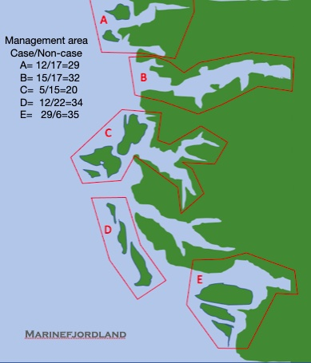

Figura 1: Areas de Manejo A, B, C, D y E de la zona MarineFjordland

## 2.- Análisis Exploratorio de Datos

# 2.1.-Descripción de las variables en estudio, factores a analizar y numero total de observaciones.

Se realiza un análisis exploratorio a la base de datos de 150 centros de cultivo, con su correspondiente información.

```r
D <- read_delim("MarineFjordland.txt")
```

```
## ──────────────────────────────────────────────────────── Delimiter: "\t" chr
## (4): SiteName, ManagementArea, Company, Vaccine dbl (6): Case,
## MeanWaterTemperature, Density, SeaLice, GillDisease, FailedSmolt lgl (1): ...11
```

# Preguntas Iniciales

¿Cuántas y qué tipo de variables se dispone para el análisis? 8 variables: Area de manejo (cualitativa nominal), Compañia (cualitativa nominal), Tipo de vacuna (cualitativa nominal), Temperatura promedio (cuantitativo continuo), Densidad (cuantitativo continuo), Presencia de Sealice (variable aleatoria discreta con distribucion bernoulli), Enfermedad branquial (variable aleatoria discreta con distribucion bernoulli), Calidad de smolt (variable aleatoria discreta con distribucion bernoulli).

¿Cuales son los tratamientos? Caso 1 (positivo, es decir mortalidad mayor al 5% diario),

Caso 0 (negativo, es decir no se registra mortalidad mayor al 5% diario), variable aleatoria discreta con distribucion bernoulli

¿La base de datos está completa?, ¿tiene errores? Si está completa y no tiene errores

¿Es posible responder las causas de mortalidad con los datos disponibles? Si, es posible.

¿La cantidad de datos y variables permite hacer un análisis estadistico? Si, el número de observaciones y las variables permiten realizar un análisis estadístico.

# 2.2.- Resumen y Visualización

# 2.2.1.- Tabla resumen

```r
datatable(D,caption="Base de datos")
```

|  | SiteName | ManagementArea | Case | MeanWaterTemperature | Density | Company | Vaccine | SeaLice | GillDisease | FailedSmolt | ...11 |
| --- | --- | --- | --- | --- | --- | --- | --- | --- | --- | --- | --- |
| 1 | SiteName1 | C | 0 | 9 | 7.6 | FishyMcFishface | Pinj | 0 | 0 | 0 |  |
| 2 | SiteName2 | A | 0 | 6.6 | 11.4 | Salmodaz | Dban | 1 | 0 | 0 |  |
| 3 | SiteName3 | C | 0 | 8.5 | 11.5 | Salmodaz | Dban | 1 | 0 | 0 |  |
| 4 | SiteName4 | A | 1 | 7 | 7.77 | Salmodaz | Dban | 1 | 0 | 1 |  |
| 5 | SiteName5 | A | 1 | 7 | 9.94 | Salarvate | Dban | 1 | 0 | 0 |  |
| 6 | SiteName6 | C | 0 | 8.7 | 4.97 | Salmodaz | MacroA | 1 | 0 | 0 |  |
| 7 | SiteName7 | E | 1 | 11.3 | 31.4 | Salmodaz | MacroA | 1 | 0 | 0 |  |
| 8 | SiteName8 | A | 1 | 6.5 | 18 | Salarvate | Dban | 0 | 0 | 0 |  |
| 9 | SiteName9 | D | 1 | 10 | 14.4 | Salmodaz | MacroA | 1 | 0 | 0 |  |
| 10 | SiteName10 | B | 0 | 8.1 | 5.69 | Piskie | Pinj | 0 | 1 | 0 |  |

[output cut: 140 more lines]

# 2.2.2.- Densidad de Cultivo

```r
resumen<-D%>%group_by(Case)%>%summarise(N=n(), mean(Density), Variance= var(Density))
kable(resumen)
```

| Case | N | mean(Density) | Variance |
| --- | --- | --- | --- |
| 0 | 77 | 10.53896 | 21.04195 |
| 1 | 73 | 14.09205 | 38.33200 |

En este caso, como se aprecia en la tabla de frecuencia los datos de densidad de cultivos se encuentran balanceados al disponer se número de datos similares para casos con y sin mortalidad, lo que permitirá hacer un adecuado análisis.

# 2.2.3.- Centros de Cultivo por area de Manejo

A continuación se describe la cantidad de centros de cultivos que tenían producción por área de producción.

```r
table(D$ManagementArea)
```

```
##
##  A  B  C  D  E
## 29 32 20 34 35
```

En relación con las zonas de producción y cuantos centros de cultivos están operando, se puede aprecia en la tabla de frecuencia, primero que todas las zonas cuentas con centros de producción y por ende datos para analizar y además se encuentran balanceados los números de centros por zona de producción.

# 2.2.4.- Mortalidad por area de manejo

# Casos Totales 0=negativo 1= caso positivo

```r
table(D$Case, D$ManagementArea)
```

```
##
##      A  B  C  D  E
##   0 17 17 15 22  6
##   1 12 15  5 12 29
```

Si observamos la tabla de frecuencia, en relación con las zonas de producción y la existencia de datos sobre centros con y sin mortalidad, vemos que en todas las zonas hay centros que presentaron mortalidad y no, vemos información balaceada de datos en las zonas A, B, sin embargo, en las zonas C y D mayor numero de centros no tuvieron mortalidad (caso 0) y por lado la zona E tuvo mayor numero de centros con mortalidad (caso 1). Creo que, si bien las hay un desbalance de centros para cada condición, es posible analizar debido a la aleatoriedad de los casos de mortalidad, pudiendo incluso establecerse una hipótesis respecto a la zona de producción y su relación con la mortalidad (caso 1).

Dentro de todas las variables, para este trabajo se decidió mostrar el analisis de sólo 2 variables Temperatura y Densidad, para luego ver la correlación de la variable Densidad y Caso (1), decir relación entre densidad y la presencia de mortalidad diaria mayor al 5%.

# 2.3.- Histograma Temperatura promedio

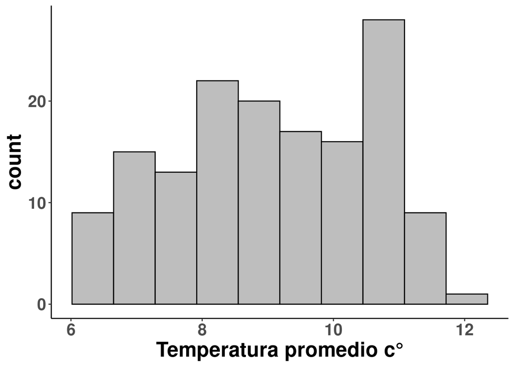

```r
ggplot(D, aes(x=D$MeanWaterTemperature))+
  geom_histogram(color="black", fill="grey", bins = 10)+theme_classic()+theme(text = element_text(size=20,face="bold",colour="black"))+xlab("Temperatura promedio c°")
```

# 2.4.- Gráfico Bloxpot asociando T° promedio con Caso

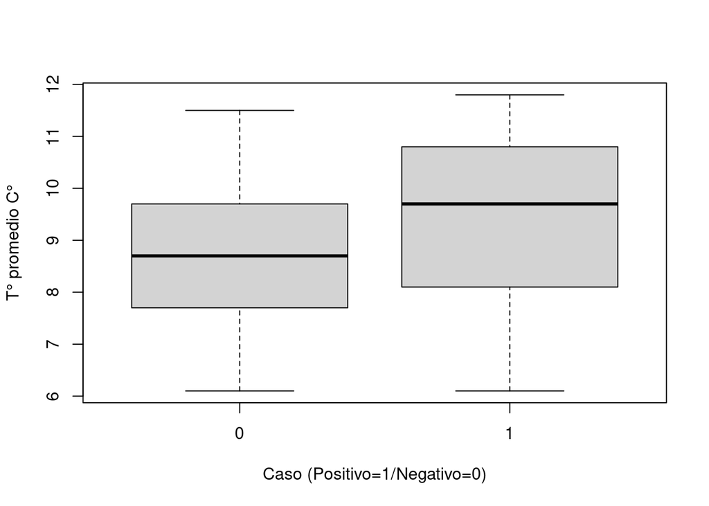

```r
boxplot(D$MeanWaterTemperature~D$Case, xlab= "Caso (Positivo=1/Negativo=0)", ylab="T° promedio C°")
```

# 2.5.- QQplot para ver la normalidad de los datos de Temperatura del agua

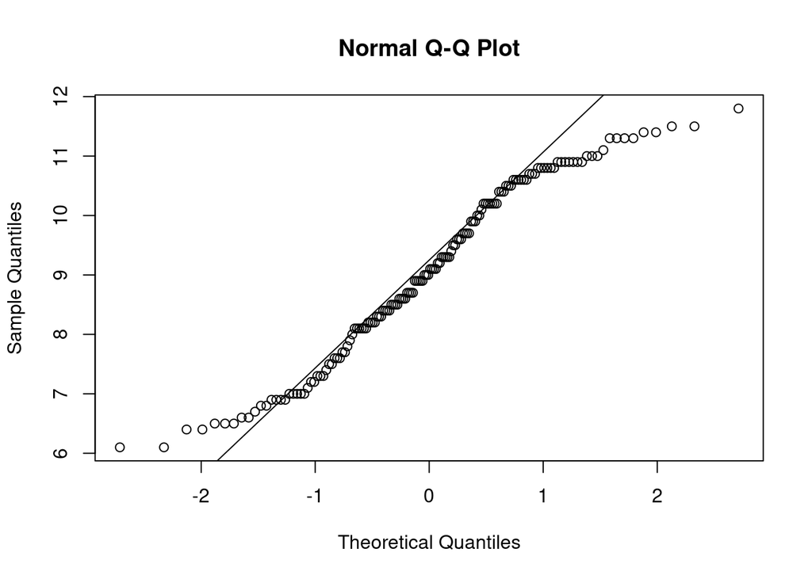

```r
qqnorm(D$MeanWaterTemperature)
qqline(D$MeanWaterTemperature)
```

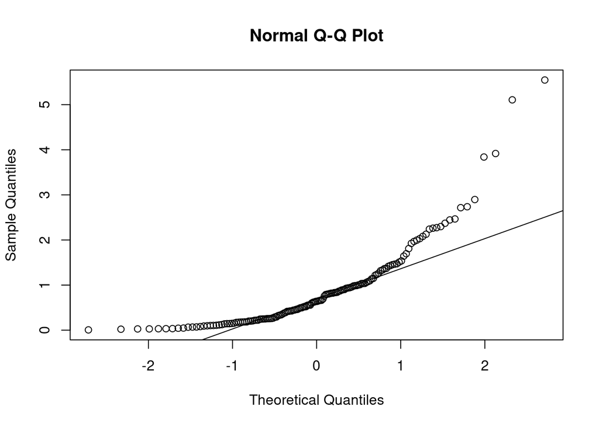

```r
D$MeanWaterTemperature <- rgamma (150, 1)
qqnorm (D$MeanWaterTemperature)
qqline (D$MeanWaterTemperature)
```